# (Bike Trip Data Exploration)

## Preliminary Wrangling

> This document explores a dataset containing duration time, member age and gender type for 174952 trips.

```python
# import all packages and set plots to be embedded inline
import numpy as np
import pandas as pd
import matplotlib.pyplot as plt
import seaborn as sb
import datetime as dt

%matplotlib inline
```

> After import libraries, Start Exploration by gather, assess and clean

```python
# Load ind the dataset into a pandas dataframe then print statistics
biketrip = pd.read_csv("fordgobike-tripdata.csv")
```

```python
# overview of data shape and composition
biketrip.shape
```

```
(183412, 16)
```

```python
biketrip.info()
biketrip.head(10)
```

```
<class 'pandas.core.frame.DataFrame'>
RangeIndex: 183412 entries, 0 to 183411
Data columns (total 16 columns):
 #   Column                   Non-Null Count   Dtype
---  ------                   --------------   -----
 0   duration_sec             183412 non-null  int64
 1   start_time               183412 non-null  object
 2   end_time                 183412 non-null  object
 3   start_station_id         183215 non-null  float64
 4   start_station_name       183215 non-null  object
 5   start_station_latitude   183412 non-null  float64
 6   start_station_longitude  183412 non-null  float64
 7   end_station_id           183215 non-null  float64
 8   end_station_name         183215 non-null  object
 9   end_station_latitude     183412 non-null  float64
 10  end_station_longitude    183412 non-null  float64
 11  bike_id                  183412 non-null  int64
 12  user_type                183412 non-null  object
 13  member_birth_year        175147 non-null  float64
 14  member_gender            175147 non-null  object
 15  bike_share_for_all_trip  183412 non-null  object
dtypes: float64(7), int64(2), object(7)
memory usage: 22.4+ MB
```

|  | duration_sec | start_time | end_time | start_station_id | start_station_name | start_station_latitude | start_station_longitude | end_station_id | end_station_name | end_station_latitude | end_station_longitude | bike_id | user_type | member_birth_year | member_gender | bike_share_for_all_trip |
| --- | --- | --- | --- | --- | --- | --- | --- | --- | --- | --- | --- | --- | --- | --- | --- | --- |
| 0 | 52185 | 2019-02-28 17:32:10.1450 | 2019-03-01 08:01:55.9750 | 21.0 | Montgomery St BART Station (Market St at 2nd St) | 37.789625 | -122.400811 | 13.0 | Commercial St at Montgomery St | 37.794231 | -122.402923 | 4902 | Customer | 1984.0 | Male | No |
| 1 | 42521 | 2019-02-28 18:53:21.7890 | 2019-03-01 06:42:03.0560 | 23.0 | The Embarcadero at Steuart St | 37.791464 | -122.391034 | 81.0 | Berry St at 4th St | 37.775880 | -122.393170 | 2535 | Customer | NaN | NaN | No |
| 2 | 61854 | 2019-02-28 12:13:13.2180 | 2019-03-01 05:24:08.1460 | 86.0 | Market St at Dolores St | 37.769305 | -122.426826 | 3.0 | Powell St BART Station (Market St at 4th St) | 37.786375 | -122.404904 | 5905 | Customer | 1972.0 | Male | No |
| 3 | 36490 | 2019-02-28 17:54:26.0100 | 2019-03-01 04:02:36.8420 | 375.0 | Grove St at Masonic Ave | 37.774836 | -122.446546 | 70.0 | Central Ave at Fell St | 37.773311 | -122.444293 | 6638 | Subscriber | 1989.0 | Other | No |
| 4 | 1585 | 2019-02-28 23:54:18.5490 | 2019-03-01 00:20:44.0740 | 7.0 | Frank H Ogawa Plaza | 37.804562 | -122.271738 | 222.0 | 10th Ave at E 15th St | 37.792714 | -122.248780 | 4898 | Subscriber | 1974.0 | Male | Yes |
| 5 | 1793 | 2019-02-28 23:49:58.6320 | 2019-03-01 00:19:51.7600 | 93.0 | 4th St at Mission Bay Blvd S | 37.770407 | -122.391198 | 323.0 | Broadway at Kearny | 37.798014 | -122.405950 | 5200 | Subscriber | 1959.0 | Male | No |
| 6 | 1147 | 2019-02-28 23:55:35.1040 | 2019-03-01 00:14:42.5880 | 300.0 | Palm St at Willow St | 37.317298 | -121.884995 | 312.0 | San Jose Diridon Station | 37.329732 | -121.901782 | 3803 | Subscriber | 1983.0 | Female | No |
| 7 | 1615 | 2019-02-28 23:41:06.7660 | 2019-03-01 00:08:02.7560 | 10.0 | Washington St at Kearny St | 37.795393 | -122.404770 | 127.0 | Valencia St at 21st St | 37.756708 | -122.421025 | 6329 | Subscriber | 1989.0 | Male | No |
| 8 | 1570 | 2019-02-28 23:41:48.7900 | 2019-03-01 00:07:59.7150 | 10.0 | Washington St at Kearny St | 37.795393 | -122.404770 | 127.0 | Valencia St at 21st St | 37.756708 | -122.421025 | 6548 | Subscriber | 1988.0 | Other | No |
| 9 | 1049 | 2019-02-28 23:49:47.6990 | 2019-03-01 00:07:17.0250 | 19.0 | Post St at Kearny St | 37.788975 | -122.403452 | 121.0 | Mission Playground | 37.759210 | -122.421339 | 6488 | Subscriber | 1992.0 | Male | No |

```python
biketrip.isnull().sum()
```

```
duration_sec                  0
start_time                    0
end_time                      0
start_station_id            197
start_station_name          197
start_station_latitude        0
start_station_longitude       0
end_station_id              197
end_station_name            197
end_station_latitude          0
end_station_longitude         0
bike_id                       0
user_type                     0
member_birth_year          8265
member_gender              8265
bike_share_for_all_trip       0
dtype: int64
```

```python
# Clean null values
biketrip_clean = biketrip.copy()
```

```python
biketrip_clean = biketrip_clean.dropna(how = 'any')
```

```python
biketrip_clean.info()
```

```
<class 'pandas.core.frame.DataFrame'>
Int64Index: 174952 entries, 0 to 183411
Data columns (total 16 columns):
 #   Column                   Non-Null Count   Dtype
---  ------                   --------------   -----
 0   duration_sec             174952 non-null  int64
 1   start_time               174952 non-null  object
 2   end_time                 174952 non-null  object
 3   start_station_id         174952 non-null  float64
 4   start_station_name       174952 non-null  object
 5   start_station_latitude   174952 non-null  float64
 6   start_station_longitude  174952 non-null  float64
 7   end_station_id           174952 non-null  float64
 8   end_station_name         174952 non-null  object
 9   end_station_latitude     174952 non-null  float64
 10  end_station_longitude    174952 non-null  float64
 11  bike_id                  174952 non-null  int64
 12  user_type                174952 non-null  object
 13  member_birth_year        174952 non-null  float64
 14  member_gender            174952 non-null  object
 15  bike_share_for_all_trip  174952 non-null  object
dtypes: float64(7), int64(2), object(7)
memory usage: 22.7+ MB
```

```python
biketrip_clean['member_birth_year'] = biketrip_clean.member_birth_year.astype(int)
```

```python
biketrip_clean.info()
```

```
<class 'pandas.core.frame.DataFrame'>
Int64Index: 174952 entries, 0 to 183411
Data columns (total 16 columns):
 #   Column                   Non-Null Count   Dtype
---  ------                   --------------   -----
 0   duration_sec             174952 non-null  int64
 1   start_time               174952 non-null  object
 2   end_time                 174952 non-null  object
 3   start_station_id         174952 non-null  float64
 4   start_station_name       174952 non-null  object
 5   start_station_latitude   174952 non-null  float64
 6   start_station_longitude  174952 non-null  float64
 7   end_station_id           174952 non-null  float64
 8   end_station_name         174952 non-null  object
 9   end_station_latitude     174952 non-null  float64
 10  end_station_longitude    174952 non-null  float64
 11  bike_id                  174952 non-null  int64
 12  user_type                174952 non-null  object
 13  member_birth_year        174952 non-null  int32
 14  member_gender            174952 non-null  object
 15  bike_share_for_all_trip  174952 non-null  object
dtypes: float64(6), int32(1), int64(2), object(7)
memory usage: 22.0+ MB
```

```python
# calculate member age, by member birth year min BikeTrip year - 2019
biketrip_clean['member_age'] = 2019 - biketrip_clean['member_birth_year']
```

```python
# calculate duration minute, by duration sec / 60
biketrip_clean['duration_minute'] = biketrip_clean['duration_sec'] // 60
```

```python
# change type of duration minute to float
biketrip_clean['duration_minute'] = biketrip_clean.duration_minute.astype(float)
```

```python
biketrip_clean.sample(10)
```

|  | duration_sec | start_time | end_time | start_station_id | start_station_name | start_station_latitude | start_station_longitude | end_station_id | end_station_name | end_station_latitude | end_station_longitude | bike_id | user_type | member_birth_year | member_gender | bike_share_for_all_trip | member_age | duration_minute |
| --- | --- | --- | --- | --- | --- | --- | --- | --- | --- | --- | --- | --- | --- | --- | --- | --- | --- | --- |
| 96530 | 775 | 2019-02-15 10:08:58.5480 | 2019-02-15 10:21:53.6660 | 248.0 | Telegraph Ave at Ashby Ave | 37.855956 | -122.259795 | 238.0 | MLK Jr Way at University Ave | 37.871719 | -122.273068 | 1739 | Subscriber | 1982 | Male | No | 37 | 12.0 |
| 170382 | 514 | 2019-02-04 08:15:36.9200 | 2019-02-04 08:24:11.6430 | 364.0 | China Basin St at 3rd St | 37.772000 | -122.389970 | 36.0 | Folsom St at 3rd St | 37.783830 | -122.398870 | 4813 | Subscriber | 1989 | Female | No | 30 | 8.0 |
| 183407 | 480 | 2019-02-01 00:04:49.7240 | 2019-02-01 00:12:50.0340 | 27.0 | Beale St at Harrison St | 37.788059 | -122.391865 | 324.0 | Union Square (Powell St at Post St) | 37.788300 | -122.408531 | 4832 | Subscriber | 1996 | Male | No | 23 | 8.0 |
| 112241 | 1066 | 2019-02-12 15:43:41.9920 | 2019-02-12 16:01:28.2640 | 324.0 | Union Square (Powell St at Post St) | 37.788300 | -122.408531 | 6.0 | The Embarcadero at Sansome St | 37.804770 | -122.403234 | 4923 | Customer | 1982 | Male | No | 37 | 17.0 |
| 48573 | 562 | 2019-02-22 07:34:40.9880 | 2019-02-22 07:44:03.4410 | 127.0 | Valencia St at 21st St | 37.756708 | -122.421025 | 89.0 | Division St at Potrero Ave | 37.769218 | -122.407646 | 5413 | Subscriber | 1988 | Male | No | 31 | 9.0 |
| 141434 | 952 | 2019-02-07 17:52:19.7000 | 2019-02-07 18:08:12.1680 | 90.0 | Townsend St at 7th St | 37.771058 | -122.402717 | 72.0 | Page St at Scott St | 37.772406 | -122.435650 | 4635 | Subscriber | 1987 | Male | No | 32 | 15.0 |
| 39871 | 1091 | 2019-02-23 00:18:37.0730 | 2019-02-23 00:36:48.2860 | 371.0 | Lombard St at Columbus Ave | 37.802746 | -122.413579 | 343.0 | Bryant St at 2nd St | 37.783172 | -122.393572 | 6251 | Subscriber | 1974 | Female | No | 45 | 18.0 |
| 14427 | 634 | 2019-02-27 12:18:53.9690 | 2019-02-27 12:29:28.4900 | 66.0 | 3rd St at Townsend St | 37.778742 | -122.392741 | 93.0 | 4th St at Mission Bay Blvd S | 37.770407 | -122.391198 | 5193 | Subscriber | 1988 | Male | No | 31 | 10.0 |
| 75201 | 396 | 2019-02-19 09:18:31.5480 | 2019-02-19 09:25:07.7170 | 258.0 | University Ave at Oxford St | 37.872355 | -122.266447 | 256.0 | Hearst Ave at Euclid Ave | 37.875112 | -122.260553 | 4781 | Subscriber | 1996 | Female | No | 23 | 6.0 |
| 163250 | 74 | 2019-02-05 09:35:06.3750 | 2019-02-05 09:36:20.7590 | 156.0 | Stanford Ave at Hollis St | 37.838443 | -122.288665 | 156.0 | Stanford Ave at Hollis St | 37.838443 | -122.288665 | 4548 | Subscriber | 1963 | Other | No | 56 | 1.0 |

```python
# Save dataframe
biketrip_clean.to_csv('biketrip.csv', encoding = 'utf-8')
```

```python
# Read dataframe
biketrip = pd.read_csv('biketrip.csv')
```

```python
biketrip.info()
```

```
<class 'pandas.core.frame.DataFrame'>
RangeIndex: 174952 entries, 0 to 174951
Data columns (total 19 columns):
 #   Column                   Non-Null Count   Dtype
---  ------                   --------------   -----
 0   Unnamed: 0               174952 non-null  int64
 1   duration_sec             174952 non-null  int64
 2   start_time               174952 non-null  object
 3   end_time                 174952 non-null  object
 4   start_station_id         174952 non-null  float64
 5   start_station_name       174952 non-null  object
 6   start_station_latitude   174952 non-null  float64
 7   start_station_longitude  174952 non-null  float64
 8   end_station_id           174952 non-null  float64
 9   end_station_name         174952 non-null  object
 10  end_station_latitude     174952 non-null  float64
 11  end_station_longitude    174952 non-null  float64
 12  bike_id                  174952 non-null  int64
 13  user_type                174952 non-null  object
 14  member_birth_year        174952 non-null  int64
 15  member_gender            174952 non-null  object
 16  bike_share_for_all_trip  174952 non-null  object
 17  member_age               174952 non-null  int64
 18  duration_minute          174952 non-null  float64
dtypes: float64(7), int64(5), object(7)
memory usage: 25.4+ MB
```

```python
biketrip.sample(10)
```

|  | Unnamed: 0 | duration_sec | start_time | end_time | start_station_id | start_station_name | start_station_latitude | start_station_longitude | end_station_id | end_station_name | end_station_latitude | end_station_longitude | bike_id | user_type | member_birth_year | member_gender | bike_share_for_all_trip | member_age | duration_minute |
| --- | --- | --- | --- | --- | --- | --- | --- | --- | --- | --- | --- | --- | --- | --- | --- | --- | --- | --- | --- |
| 117500 | 123065 | 2455 | 2019-02-11 09:19:24.6810 | 2019-02-11 10:00:20.2120 | 163.0 | Lake Merritt BART Station | 37.797320 | -122.265320 | 187.0 | Jack London Square | 37.796248 | -122.279352 | 4882 | Subscriber | 1962 | Female | Yes | 57 | 40.0 |
| 128560 | 134780 | 345 | 2019-02-08 16:53:50.0050 | 2019-02-08 16:59:35.1160 | 25.0 | Howard St at 2nd St | 37.787522 | -122.397405 | 47.0 | 4th St at Harrison St | 37.780955 | -122.399749 | 2123 | Subscriber | 1975 | Male | No | 44 | 5.0 |
| 95994 | 100702 | 195 | 2019-02-14 18:13:08.5610 | 2019-02-14 18:16:24.2560 | 11.0 | Davis St at Jackson St | 37.797280 | -122.398436 | 16.0 | Steuart St at Market St | 37.794130 | -122.394430 | 3359 | Subscriber | 1975 | Male | No | 44 | 3.0 |
| 53506 | 55966 | 1215 | 2019-02-21 09:12:48.2470 | 2019-02-21 09:33:03.3670 | 120.0 | Mission Dolores Park | 37.761420 | -122.426435 | 50.0 | 2nd St at Townsend St | 37.780526 | -122.390288 | 3391 | Subscriber | 1988 | Male | No | 31 | 20.0 |
| 166544 | 174486 | 1567 | 2019-02-02 17:41:07.4530 | 2019-02-02 18:07:14.8830 | 78.0 | Folsom St at 9th St | 37.773717 | -122.411647 | 44.0 | Civic Center/UN Plaza BART Station (Market St ... | 37.781074 | -122.411738 | 4554 | Subscriber | 1981 | Male | No | 38 | 26.0 |
| 5643 | 5885 | 357 | 2019-02-28 11:54:24.0550 | 2019-02-28 12:00:21.7350 | 26.0 | 1st St at Folsom St | 37.787290 | -122.394380 | 284.0 | Yerba Buena Center for the Arts (Howard St at ... | 37.784872 | -122.400876 | 6072 | Subscriber | 1987 | Male | No | 32 | 5.0 |
| 174515 | 182948 | 897 | 2019-02-01 07:22:17.3360 | 2019-02-01 07:37:14.8400 | 118.0 | Eureka Valley Recreation Center | 37.759177 | -122.436943 | 104.0 | 4th St at 16th St | 37.767045 | -122.390833 | 4770 | Subscriber | 1991 | Female | No | 28 | 14.0 |
| 167253 | 175245 | 1835 | 2019-02-02 14:36:25.9900 | 2019-02-02 15:07:01.6380 | 24.0 | Spear St at Folsom St | 37.789677 | -122.390428 | 24.0 | Spear St at Folsom St | 37.789677 | -122.390428 | 5502 | Subscriber | 1974 | Female | Yes | 45 | 30.0 |
| 35689 | 37219 | 386 | 2019-02-23 14:37:22.3500 | 2019-02-23 14:43:48.9520 | 194.0 | Lakeshore Ave at Trestle Glen Rd | 37.811081 | -122.243268 | 193.0 | Grand Ave at Santa Clara Ave | 37.812744 | -122.247215 | 1528 | Subscriber | 1990 | Female | No | 29 | 6.0 |
| 65807 | 68809 | 172 | 2019-02-19 21:08:39.2240 | 2019-02-19 21:11:31.9110 | 72.0 | Page St at Scott St | 37.772406 | -122.435650 | 85.0 | Church St at Duboce Ave | 37.770083 | -122.429156 | 4456 | Subscriber | 1964 | Male | No | 55 | 2.0 |

### What is the structure of your dataset?

> Calculate member bike trips between duration minutes, member age and gender type. we use matplotlib and seborn libraries to draw many clear chart.

### What is/are the main feature(s) of interest in your dataset?

> Member age and genders - to get full information about which the best age for fit and which the genders is fit more.

### What features in the dataset do you think will help support your investigation into your feature(s) of interest?

> The fitness of member with defrence age and genders, and which duration time expended less than anothers.

## Univariate Exploration

> I will start by looking at the main variable of interest: member age. that will get us the best age fit.

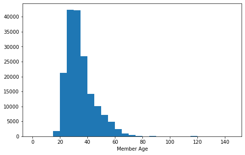

```python
# start with univariate plot
binsize = 5
bins = np.arange(0, biketrip['member_age'].max()+binsize, binsize)
plt.figure(figsize=[8, 5])
plt.hist(data = biketrip, x = 'member_age', bins = bins)
plt.xlabel('Member Age')
plt.show()
```

[figure not shown]

```python
bins = np.arange(0, biketrip['member_age'].max()+0.2, 0.2)
plt.hist(data=biketrip, x='height', bins=bins);
plt.xlim((0,6));
```

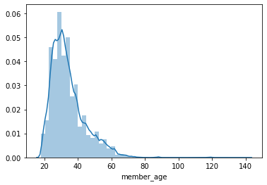

```python
sb.distplot(biketrip['member_age']);
```

> The specital arange of good fitness between 20 to 40 age.

### Discuss the distribution(s) of your variable(s) of interest. Were there any unusual points? Did you need to perform any transformations?

> I create new column `member_age` by calculate between `member_birth_year` min of trip date 2019, that get us more information details cleared.

### Of the features you investigated, were there any unusual distributions? Did you perform any operations on the data to tidy, adjust, or change the form of the data? If so, why did you do this?

> Of course, need to change some of data like -I need member age to compaire which generation is good fit- by use some calculate of columns. these will give us more details.

## Bivariate Exploration

> Here will compire between member gender and duration minute to check which of gender is fit.

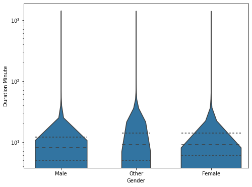

```python
# Bivariate Exploration
plt.figure(figsize = [8, 6])
default_color = sb.color_palette()[0]
sb.violinplot(data = biketrip, x = 'member_gender', y = 'duration_minute', color=default_color, inner='quartile')
plt.xlabel('Gender')
plt.yscale('log')
plt.ylabel('Duration Minute')
plt.show()
```

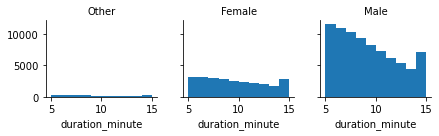

```python
group_means = biketrip.groupby(['member_gender']).mean()
group_order = group_means.sort_values(['duration_minute'], ascending = False).index

g = sb.FacetGrid(data = biketrip, col = 'member_gender', col_wrap = 5, size = 2,
                 col_order = group_order)
g.map(plt.hist, 'duration_minute', bins = np.arange(5, 15+1, 1))
g.set_titles('{col_name}')
```

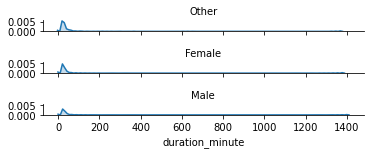

```python
group_means = biketrip.groupby(['member_gender']).mean()
group_order = group_means.sort_values(['duration_minute'], ascending = False).index

g = sb.FacetGrid(data = biketrip, row = 'member_gender', size = 0.75, aspect = 7,
                 row_order = group_order)
g.map(sb.kdeplot, 'duration_minute', shade = True)
g.set_titles('{row_name}')
```

## Multivariate Exploration

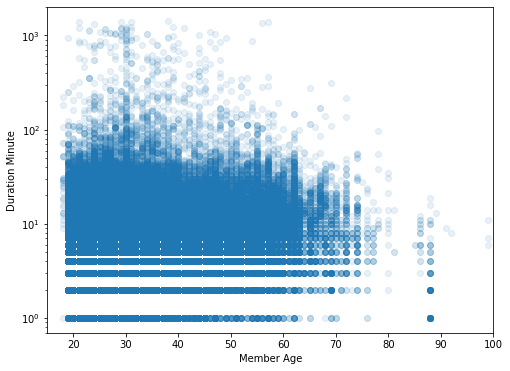

```python
# Multivariate Exploration

plt.figure(figsize = [8, 6])
plt.scatter(data = biketrip, x = 'member_age', y = 'duration_minute', alpha = 1/10)
plt.xlim([15, 100])
plt.xlabel('Member Age')
plt.yscale('log')
plt.ylabel('Duration Minute')
plt.show()
```

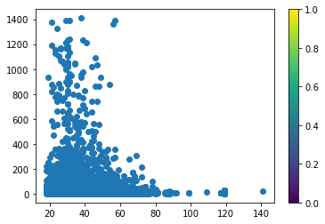

```python
plt.scatter(data = biketrip, x = 'member_age', y = 'duration_minute')
plt.colorbar()
```

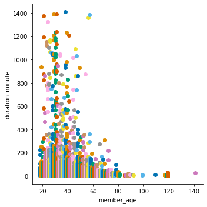

```python
g = sb.FacetGrid(data = biketrip, hue = 'member_age', size = 5,
                 palette = 'colorblind')
g.map(plt.scatter, 'member_age', 'duration_minute')
```

### Talk about some of the relationships you observed in this part of the investigation. Were there features that strengthened each other in terms of looking at your feature(s) of interest?

> Here compire between member age with duration minute, there are a lot between 20 and 40 age. because this ages more fit rather the another who less, because the young ages is win.